# Brief vignette on linear models.

## Multivariate normals and linear transformations.

We first generate a bunch of data points from the bivariate normal with mean $0$ and identity covariance matrix. We then draw the scatterplot for these points and the super-imposed the **countours** for the pdf of the bivariate normal with identity covariance matrix on top of the scatter plot. The **contours** are concentric circles in this case.

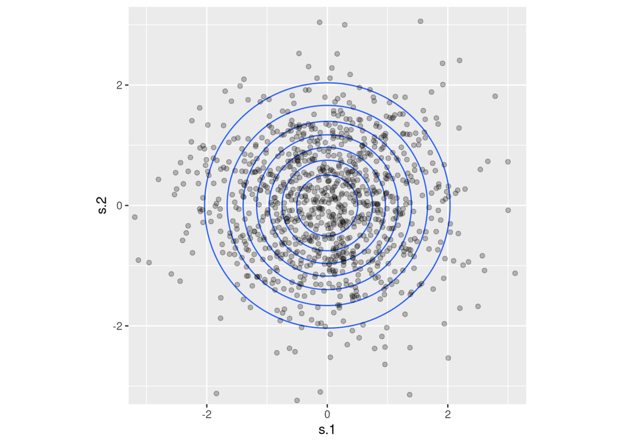

```r
library(ggplot2)
m <- c(0,0)
sigma <- matrix(c(1,0,0,1),nrow = 2)
data.grid <- expand.grid(s.1 = seq(-3, 3, length.out=200), s.2 = seq(-3, 3, length.out=200))
q.samp <- cbind(data.grid, prob = mvtnorm::dmvnorm(data.grid, mean = m, sigma = sigma))
df <- data.frame(x = rnorm(1000),y = rnorm(1000))
ggplot(q.samp, aes(x=s.1, y=s.2)) +
    geom_contour(aes(z = prob)) +
    coord_fixed(xlim = c(-3, 3), ylim = c(-3, 3), ratio = 1) +
  geom_point(data = df, aes (x = x,y = y), alpha = 0.25)
```

We now transform the data through some simple linear transformations.

```r
library(dplyr)
df_transformed <- df %>% mutate(x2 = 2*x - y + 1, y2 = 0.5*x + 2*y - 1) %>%
  select(x2,y2) %>%
  rename(x = x2, y = y2)
Tmat <- matrix(c(2,-1,0.5,2),nrow = 2, byrow = TRUE)
Tmat
```

```
##      [,1] [,2]
## [1,]  2.0   -1
## [2,]  0.5    2
```

```r
sigma_transformed <- Tmat %*% sigma %*% t(Tmat)
sigma_transformed ## Transformation of covariance matrix
```

```
##      [,1]  [,2]
## [1,]    5 -1.00
## [2,]   -1  4.25
```

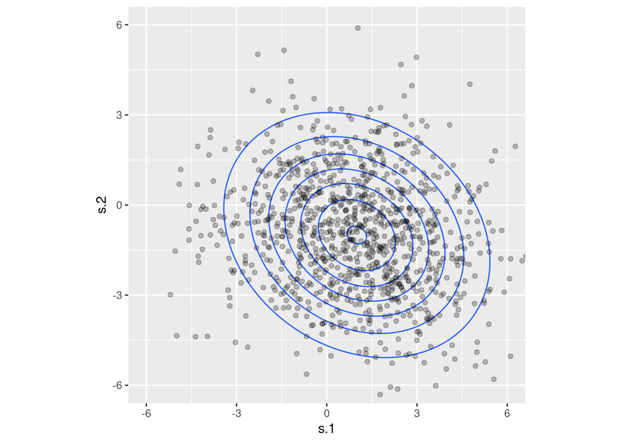

```r
m_transformed <- Tmat %*% m + c(1,-1) ## transformation of mean.
data.grid <- expand.grid(s.1 = seq(-6, 6, length.out=200), s.2 = seq(-6, 6, length.out=200))
q.samp <- cbind(data.grid, prob = mvtnorm::dmvnorm(data.grid, mean = m_transformed, sigma = sigma_transformed))
ggplot(q.samp, aes(x=s.1, y=s.2)) +
    geom_contour(aes(z = prob)) +
    coord_fixed(xlim = c(-6, 6), ylim = c(-6, 6), ratio = 1) +
  geom_point(data = df_transformed, aes (x = x,y = y), alpha = 0.25)
```

We see that the points are transformed accordingly and furthermore, the **contours** for the transformed data are now concentric **ellipses**.

## Example 1. SAT and spending

```r
library(faraway)
library(dplyr)
library(tibble)
data(sat)
sat$state <- rownames(sat)
sat <- as_tibble(sat)
sat <- sat |> select(state,everything())
sat
```

```
## # A tibble: 50 × 8
##    state       expend ratio salary takers verbal  math total
##    <chr>        <dbl> <dbl>  <dbl>  <int>  <int> <int> <int>
##  1 Alabama       4.40  17.2   31.1      8    491   538  1029
##  2 Alaska        8.96  17.6   48.0     47    445   489   934
##  3 Arizona       4.78  19.3   32.2     27    448   496   944
##  4 Arkansas      4.46  17.1   28.9      6    482   523  1005
##  5 California    4.99  24     41.1     45    417   485   902
##  6 Colorado      5.44  18.4   34.6     29    462   518   980
##  7 Connecticut   8.82  14.4   50.0     81    431   477   908
##  8 Delaware      7.03  16.6   39.1     68    429   468   897
##  9 Florida       5.72  19.1   32.6     48    420   469   889
## 10 Georgia       5.19  16.3   32.3     65    406   448   854
## # ℹ 40 more rows
```

This dataset contains the school expenditure and test scores for 50 USA states in 1994-95. We first fit two linear models to the data

```r
mod1 <- lm(math ~ expend, data = sat)
mod2 <- lm(math ~ expend + salary + ratio, data = sat)
```

The following summary output of `mod2` contains a bunch of information. The coefficients estimates are listed along with their estimated standard deviations, and the associated p-values for testing the marginal null hypothesis $\mathbb{H}_0 \colon \beta_j = 0, \quad \text{other coefficients arbitrary}$. The F-test statistic is for testing the null hypothesis $\mathbb{H}_0 \colon \beta_{\mathrm{expend}} = \beta_{\mathrm{salary}} = \beta_{\mathrm{ratio}} = 0$ against the alternative hypothesis that at least one of these coefficients is non-zero. We view all of these p-values as descriptive statistics (since the null hypothesis is quite artificial) in the sense that if the p-value we obtained is “unexpected” (for example suggesting no relationship between some subset of predictor variables and the response variable when we expect a relationship) then we will want to know why.

```r
summary(mod2)
```

```
##
## Call:
## lm(formula = math ~ expend + salary + ratio, data = sat)
##
## Residuals:
##    Min     1Q Median     3Q    Max
## -74.44 -24.82  -2.74  20.60  72.04
##
## Coefficients:
##             Estimate Std. Error t value Pr(>|t|)
## (Intercept)  548.824     60.658   9.048 8.88e-12 ***
## expend         9.634     12.058   0.799   0.4284
## salary        -4.636      2.568  -1.805   0.0776 .
## ratio          3.828      3.577   1.070   0.2902
## ---
## Signif. codes:  0 '***' 0.001 '**' 0.01 '*' 0.05 '.' 0.1 ' ' 1
##
## Residual standard error: 37.54 on 46 degrees of freedom
## Multiple R-squared:  0.1814, Adjusted R-squared:  0.128
## F-statistic: 3.399 on 3 and 46 DF,  p-value: 0.02548
```

The following code compares model `mod1` against model `mod2`. As `mod1` is nested in `mod2`, this comparison is equivalent to testing the null hypothesis that $\beta_{\mathrm{salary}} = \beta_{\mathrm{ratio}} = 0$ against the alternative hypothesis that at least one of these coefficients is non-zero.

```r
summary(mod1)
```

```
##
## Call:
## lm(formula = math ~ expend, data = sat)
##
## Residuals:
##     Min      1Q  Median      3Q     Max
## -77.204 -28.908   0.927  18.779  73.783
##
## Coefficients:
##             Estimate Std. Error t value Pr(>|t|)
## (Intercept)   569.65      24.17  23.571   <2e-16 ***
## expend        -10.31       3.99  -2.584   0.0129 *
## ---
## Signif. codes:  0 '***' 0.001 '**' 0.01 '*' 0.05 '.' 0.1 ' ' 1
##
## Residual standard error: 38.06 on 48 degrees of freedom
## Multiple R-squared:  0.1221, Adjusted R-squared:  0.1038
## F-statistic: 6.675 on 1 and 48 DF,  p-value: 0.01288
```

```r
anova(mod1, mod2)
```

```
## Analysis of Variance Table
##
## Model 1: math ~ expend
## Model 2: math ~ expend + salary + ratio
##   Res.Df   RSS Df Sum of Sq      F Pr(>F)
## 1     48 69534
## 2     46 64834  2      4700 1.6673    0.2
```

We see that the above comparison suggests that the two models are comparable. This is quite suprising/counter-intuitive as it suggests that increasing expenditure is associated with decreasing math scores. The following output indicates that this is due to confounding variable; in particular adding `takers` as a predictor variable decreases the MSE considerably and also make the coefficient for more intuitive.

```r
mod3 <- lm(math ~ expend + takers, data = sat)
summary(mod3)
```

```
##
## Call:
## lm(formula = math ~ expend + takers, data = sat)
##
## Residuals:
##     Min      1Q  Median      3Q     Max
## -54.274 -10.365  -1.585   9.075  45.366
##
## Coefficients:
##             Estimate Std. Error t value Pr(>|t|)
## (Intercept) 518.3012    12.4040  41.785  < 2e-16 ***
## expend        7.5394     2.3999   3.142  0.00291 **
## takers       -1.5336     0.1222 -12.549  < 2e-16 ***
## ---
## Signif. codes:  0 '***' 0.001 '**' 0.01 '*' 0.05 '.' 0.1 ' ' 1
##
## Residual standard error: 18.44 on 47 degrees of freedom
## Multiple R-squared:  0.7982, Adjusted R-squared:  0.7896
## F-statistic: 92.95 on 2 and 47 DF,  p-value: < 2.2e-16
```

We now compare mod3 against a “full” model that includes all the predictor variables. We see that mod3 is comparable to this “full” model.

```r
mod_full <- lm(math ~ expend + takers + ratio + salary, data = sat)
summary(mod_full)
```

```
##
## Call:
## lm(formula = math ~ expend + takers + ratio + salary, data = sat)
##
## Residuals:
##     Min      1Q  Median      3Q     Max
## -54.269 -10.282  -1.548   8.797  45.562
##
## Coefficients:
##             Estimate Std. Error t value Pr(>|t|)
## (Intercept) 536.2724    30.2214  17.745  < 2e-16 ***
## expend        3.1560     6.0286   0.524    0.603
## takers       -1.5672     0.1322 -11.855 1.94e-15 ***
## ratio        -1.5428     1.8380  -0.839    0.406
## salary        1.0080     1.3646   0.739    0.464
## ---
## Signif. codes:  0 '***' 0.001 '**' 0.01 '*' 0.05 '.' 0.1 ' ' 1
##
## Residual standard error: 18.69 on 45 degrees of freedom
## Multiple R-squared:  0.8015, Adjusted R-squared:  0.7838
## F-statistic: 45.42 on 4 and 45 DF,  p-value: 3.024e-15
```

```r
anova(mod3, mod_full)
```

```
## Analysis of Variance Table
##
## Model 1: math ~ expend + takers
## Model 2: math ~ expend + takers + ratio + salary
##   Res.Df   RSS Df Sum of Sq      F Pr(>F)
## 1     47 15983
## 2     45 15724  2    258.87 0.3704 0.6925
```

In summary, using model mod3, the estimated/confidence interval for the math SAT scores for the 50 US states is visualized below. The $\sqrt{\mathrm{MSE}}$ is $18.441$, and looking at the confidence intervals, suggest that the posited relationship between expenditure and math SAT score is reasonably accurate.

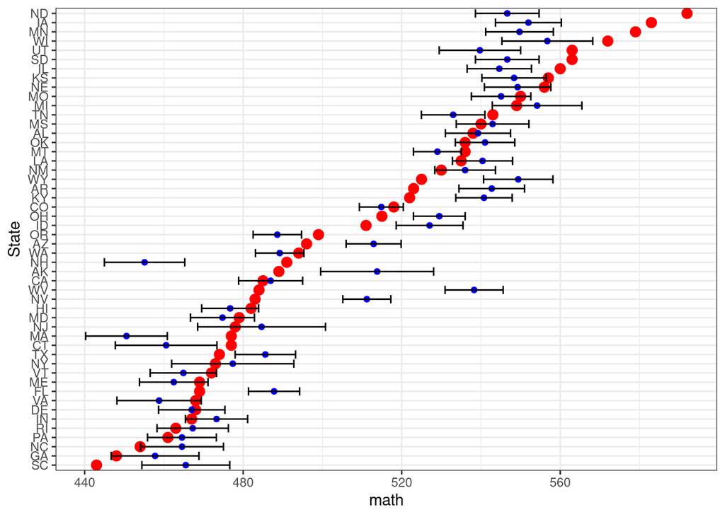

```r
library(ggplot2)
df <- cbind(sat, predict(mod3, sat, level = 0.95, interval = "confidence"))
df <- df |> mutate(abb = state.abb)

ggplot(df, aes(reorder(x = abb, math), y = math)) + geom_point(color = "red", size = 3) +
  geom_point(aes(y = fit),color = "blue") +
  geom_errorbar(aes(ymin = lwr, ymax = upr)) + xlab("State") +
  coord_flip() + theme_bw()
```

## Example 2: Outliers and linear regression

Linear regression using least square estimation can be highly non-robust in the presence of outliers. An outlier is, roughly speaking, any point that is “different” from most of the remaining points.

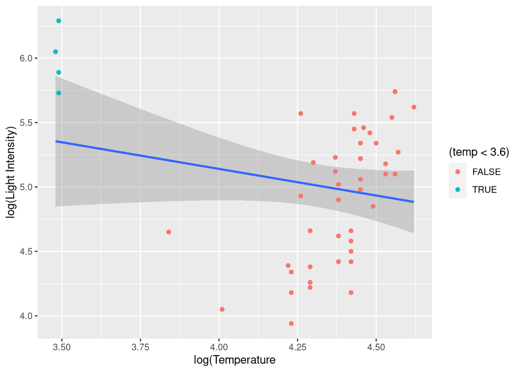

```r
library(faraway)
library(ggplot2)
data(star)
ggplot(star, aes(x = temp, y = light)) +
  xlab("log(Temperature") + ylab("log(Light Intensity)") + geom_smooth(method = "lm") +
  geom_point(aes(color = (temp < 3.6)))
```

If we now remove the eye-balled “outliers” and recompute the least square regression, we get the above plot. It is not always easy to automatically detect outliers when they occur in clusters such as in this example. What happens if the data include 3 or more predictor variables ?

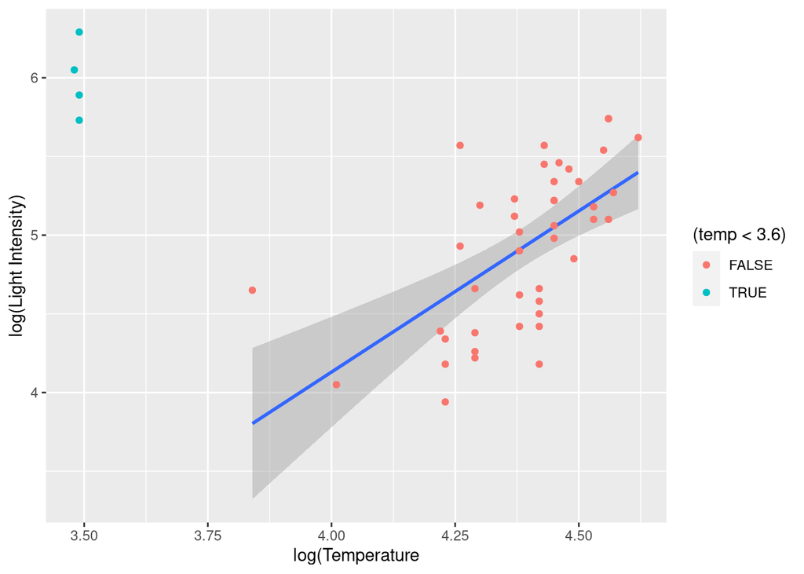

```r
library(dplyr)
ggplot(star, aes(x = temp, y = light)) +
  xlab("log(Temperature") + ylab("log(Light Intensity)") +
  geom_smooth(data = filter(star, temp > 3.6), method = "lm") +
  geom_point(aes(color = (temp < 3.6)))
```

## Example 3: Life Expectancy in Gapminder

```r
library(gapminder)
gapminder
```

```
## # A tibble: 1,704 × 6
##    country     continent  year lifeExp      pop gdpPercap
##    <fct>       <fct>     <int>   <dbl>    <int>     <dbl>
##  1 Afghanistan Asia       1952    28.8  8425333      779.
##  2 Afghanistan Asia       1957    30.3  9240934      821.
##  3 Afghanistan Asia       1962    32.0 10267083      853.
##  4 Afghanistan Asia       1967    34.0 11537966      836.
##  5 Afghanistan Asia       1972    36.1 13079460      740.
##  6 Afghanistan Asia       1977    38.4 14880372      786.
##  7 Afghanistan Asia       1982    39.9 12881816      978.
##  8 Afghanistan Asia       1987    40.8 13867957      852.
##  9 Afghanistan Asia       1992    41.7 16317921      649.
## 10 Afghanistan Asia       1997    41.8 22227415      635.
## # ℹ 1,694 more rows
```

Suppose we want to model the life expectancy of the countries in terms of the year and the `gdpPercap`. Let us try a few models.

```r
mod1 <- lm(lifeExp ~ year + gdpPercap, data = gapminder)
summary(mod1)
```

```
##
## Call:
## lm(formula = lifeExp ~ year + gdpPercap, data = gapminder)
##
## Residuals:
##     Min      1Q  Median      3Q     Max
## -67.262  -6.954   1.219   7.759  19.553
##
## Coefficients:
##               Estimate Std. Error t value Pr(>|t|)
## (Intercept) -4.184e+02  2.762e+01  -15.15   <2e-16 ***
## year         2.390e-01  1.397e-02   17.11   <2e-16 ***
## gdpPercap    6.697e-04  2.447e-05   27.37   <2e-16 ***
## ---
## Signif. codes:  0 '***' 0.001 '**' 0.01 '*' 0.05 '.' 0.1 ' ' 1
##
## Residual standard error: 9.694 on 1701 degrees of freedom
## Multiple R-squared:  0.4375, Adjusted R-squared:  0.4368
## F-statistic: 661.4 on 2 and 1701 DF,  p-value: < 2.2e-16
```

The previous model output looks ok, except that the coefficients are not particularly meaningful since the year goes from 1952 to 2007, which renders the intercept coefficient irrelevant (as $year=0$ is never included in the model). We therefore subtract `1952` from all the years. Similarly, the `gdpPercap` unit here is in dollars, and most countries have `gdpPercap` in a wide-range of values. This suggest looking at a logarithmic transform of the `gdpPercap`.

```r
mod1_alt <- lm(lifeExp ~ I(year - 1952) + log(gdpPercap), data = gapminder)
summary(mod1_alt)
```

```
##
## Call:
## lm(formula = lifeExp ~ I(year - 1952) + log(gdpPercap), data = gapminder)
##
## Residuals:
##      Min       1Q   Median       3Q      Max
## -27.2291  -3.8454   0.6065   4.7737  17.8644
##
## Coefficients:
##                 Estimate Std. Error t value Pr(>|t|)
## (Intercept)    -9.300131   1.108141  -8.393   <2e-16 ***
## I(year - 1952)  0.195569   0.009927  19.702   <2e-16 ***
## log(gdpPercap)  7.770320   0.138084  56.273   <2e-16 ***
## ---
## Signif. codes:  0 '***' 0.001 '**' 0.01 '*' 0.05 '.' 0.1 ' ' 1
##
## Residual standard error: 6.877 on 1701 degrees of freedom
## Multiple R-squared:  0.7169, Adjusted R-squared:  0.7165
## F-statistic:  2153 on 2 and 1701 DF,  p-value: < 2.2e-16
```

We see that the coefficients values are now more interpretable. Furthermore, the mean square error decreases substantially.

### Adding qualitative predictor variables for year

Let us now change the year to be a factor, i.e., the model is now

$$\mathrm{lifeExp}_i = \beta_0 + \beta_1
\log(\mathrm{gdpPercap}) + \beta_2 \mathbb{I}\{\mathrm{year}_i == 1952\}
+ \beta_3 \mathbb{I}\{\mathrm{year}_i == 1957\} + \dots +
\epsilon_i$$

```r
mod2 <- lm(lifeExp ~ log(gdpPercap) + as.factor(year), data = gapminder)
summary(mod2)$sigma
```

```
## [1] 6.865157
```

The above is an example of using a qualitative predictor variable (in this case converting into a factor). The default category is now the year 1952.

### Adding qualitative predictor variables for country

We revert to making as a numeric variable but now introduce country as a qualitative predictor variable. The default country is Afghanistan. The model is thus

$$\mathrm{lifeExp}_i = \beta_0 +
\beta_1(\mathrm{year}_i - 1952) + \beta_2 \log(\mathrm{gdpPercap}) +
\beta_3 \mathbb{I}\{\mathrm{country}_i == "Albania"\} +
\beta_4 \mathbb{I}\{\mathrm{country}_i == "Algeria"\} + \dots
+ \epsilon_i$$

```r
mod3 <- lm(lifeExp ~ I(year - 1952) + log(gdpPercap) + country, data = gapminder)
summary(mod3)
```

```
##
## Call:
## lm(formula = lifeExp ~ I(year - 1952) + log(gdpPercap) + country,
##     data = gapminder)
##
## Residuals:
##      Min       1Q   Median       3Q      Max
## -21.7631  -1.8835   0.3205   2.1546   7.6977
##
## Coefficients:
##                                  Estimate Std. Error t value Pr(>|t|)
## (Intercept)                     16.780035   1.951243   8.600  < 2e-16 ***
## I(year - 1952)                   0.294246   0.006675  44.084  < 2e-16 ***
## log(gdpPercap)                   1.887408   0.266726   7.076 2.23e-12 ***
## countryAlbania                  28.409297   1.484975  19.131  < 2e-16 ***
## countryAlgeria                  18.400112   1.508024  12.201  < 2e-16 ***
## countryAngola                   -2.360437   1.492821  -1.581 0.114037
## countryArgentina                27.051046   1.576623  17.158  < 2e-16 ***
## countryAustralia                31.236510   1.668013  18.727  < 2e-16 ***
## countryAustria                  29.737761   1.663691  17.875  < 2e-16 ***
....
```

```r
summary(mod3)$sigma
```

```
## [1] 3.529153
```

```r
anova(mod1_alt, mod3)
```

```
## Analysis of Variance Table
##
## Model 1: lifeExp ~ I(year - 1952) + log(gdpPercap)
## Model 2: lifeExp ~ I(year - 1952) + log(gdpPercap) + country
##   Res.Df   RSS  Df Sum of Sq      F    Pr(>F)
## 1   1701 80454
## 2   1560 19430 141     61025 34.749 < 2.2e-16 ***
## ---
## Signif. codes:  0 '***' 0.001 '**' 0.01 '*' 0.05 '.' 0.1 ' ' 1
```

For this model, different countries have different intercepts. We see that this model fits the data substantially better than our initial model. However, this model now has 144 parameters.

### Adding iteractions between variables

We now add interactions between country and year. The default country is still Afghanistan. The model is thus
$$\mathrm{lifeExp}_i = \beta_0 + \beta_1
\log(\mathrm{gdpPercap}) + \beta_2 \mathbb{I}\{\mathrm{year}_i == 1952\}
+ \beta_3 \mathbb{I}\{\mathrm{country}_i == "Albania"\} +
\beta_4 \mathbb{I}\{\mathrm{country}_i == "Algeria"\} \times
(\mathrm{year}_i - 1952) + \dots + \epsilon_i$$

```r
mod4 <- lm(lifeExp ~ log(gdpPercap) + I(year - 1952)*country, data = gapminder)
summary(mod4)
```

```
##
## Call:
## lm(formula = lifeExp ~ log(gdpPercap) + I(year - 1952) * country,
##     data = gapminder)
##
## Residuals:
##      Min       1Q   Median       3Q      Max
## -17.2997  -0.7618   0.0839   0.8264  10.1041
##
## Coefficients:
##                                                 Estimate Std. Error t value
## (Intercept)                                     8.317318   2.247059   3.701
## log(gdpPercap)                                  3.219981   0.289148  11.136
## I(year - 1952)                                  0.278308   0.034990   7.954
## countryAlbania                                 26.568916   1.625498  16.345
## countryAlgeria                                  9.597596   1.643748   5.839
## countryAngola                                  -3.043558   1.674659  -1.817
## countryArgentina                               26.016094   1.717607  15.147
## countryAustralia                               30.386945   1.763806  17.228
## countryAustria                                 29.244939   1.735051  16.855
....
```

```r
summary(mod4)$sigma
```

```
## [1] 2.092057
```

```r
anova(mod3, mod4)
```

```
## Analysis of Variance Table
##
## Model 1: lifeExp ~ I(year - 1952) + log(gdpPercap) + country
## Model 2: lifeExp ~ log(gdpPercap) + I(year - 1952) * country
##   Res.Df     RSS  Df Sum of Sq      F    Pr(>F)
## 1   1560 19429.7
## 2   1419  6210.5 141     13219 21.421 < 2.2e-16 ***
## ---
## Signif. codes:  0 '***' 0.001 '**' 0.01 '*' 0.05 '.' 0.1 ' ' 1
```

For this model, different countries have possibly distinct intercepts and distinct slopes. We see that this model fits the data substantially better than our model where each country have possibly distinct intercepts. However, this model now has 285 parameters.

### Visualizing the result

Let us now take model mod3. This model has 144 parameters, and the estimated standard error σ is 3.529, and so the average error for estimating the life expectancy using model mod3 is 3.529 years, a reasonable number. Let us now visualize this result for a few countries.

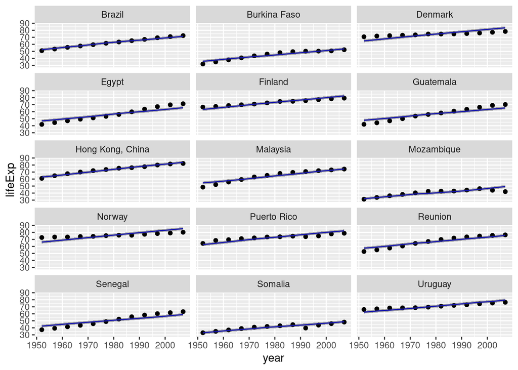

```r
gapminder.fitted <- cbind(gapminder, predict(mod3, gapminder, level = 0.95, interval = "confidence"))
set.seed(123)
gapminder.small <- gapminder.fitted %>% filter(country %in% sample(country, 15))
ggplot(gapminder.small, aes(x = year)) + geom_point(aes(y = lifeExp), color = "black") +
  geom_line(aes(y = fit, group = country),color = "blue") +
  geom_ribbon(aes(ymin = lwr, ymax = upr, group = country), alpha = 0.4) + facet_wrap(~ country, ncol = 3)
```

## Example 4. Ames housing dataset.

We now provide a more detailed example of regression analysis using the [Ames housing dataset](https://cran.r-project.org/web/packages/AmesHousing/index.html). The data was collected by Dean De Cock of Truman State University. See this [article](http://jse.amstat.org/v19n3/decock.pdf) in the Journal of Statistical Education describing the data.

```r
library(AmesHousing)
ames <- make_ames()
ames
```

```
## # A tibble: 2,930 × 81
##    MS_SubClass            MS_Zoning Lot_Frontage Lot_Area Street Alley Lot_Shape
##    <fct>                  <fct>            <dbl>    <int> <fct>  <fct> <fct>
##  1 One_Story_1946_and_Ne… Resident…          141    31770 Pave   No_A… Slightly…
##  2 One_Story_1946_and_Ne… Resident…           80    11622 Pave   No_A… Regular
##  3 One_Story_1946_and_Ne… Resident…           81    14267 Pave   No_A… Slightly…
##  4 One_Story_1946_and_Ne… Resident…           93    11160 Pave   No_A… Regular
##  5 Two_Story_1946_and_Ne… Resident…           74    13830 Pave   No_A… Slightly…
##  6 Two_Story_1946_and_Ne… Resident…           78     9978 Pave   No_A… Slightly…
##  7 One_Story_PUD_1946_an… Resident…           41     4920 Pave   No_A… Regular
##  8 One_Story_PUD_1946_an… Resident…           43     5005 Pave   No_A… Slightly…
##  9 One_Story_PUD_1946_an… Resident…           39     5389 Pave   No_A… Slightly…
## 10 Two_Story_1946_and_Ne… Resident…           60     7500 Pave   No_A… Regular
## # ℹ 2,920 more rows
## # ℹ 74 more variables: Land_Contour <fct>, Utilities <fct>, Lot_Config <fct>,
## #   Land_Slope <fct>, Neighborhood <fct>, Condition_1 <fct>, Condition_2 <fct>,
## #   Bldg_Type <fct>, House_Style <fct>, Overall_Qual <fct>, Overall_Cond <fct>,
## #   Year_Built <int>, Year_Remod_Add <int>, Roof_Style <fct>, Roof_Matl <fct>,
## #   Exterior_1st <fct>, Exterior_2nd <fct>, Mas_Vnr_Type <fct>,
## #   Mas_Vnr_Area <dbl>, Exter_Qual <fct>, Exter_Cond <fct>, Foundation <fct>, …
```

```r
names(ames)
```

```
##  [1] "MS_SubClass"        "MS_Zoning"          "Lot_Frontage"
##  [4] "Lot_Area"           "Street"             "Alley"
##  [7] "Lot_Shape"          "Land_Contour"       "Utilities"
## [10] "Lot_Config"         "Land_Slope"         "Neighborhood"
## [13] "Condition_1"        "Condition_2"        "Bldg_Type"
## [16] "House_Style"        "Overall_Qual"       "Overall_Cond"
## [19] "Year_Built"         "Year_Remod_Add"     "Roof_Style"
## [22] "Roof_Matl"          "Exterior_1st"       "Exterior_2nd"
## [25] "Mas_Vnr_Type"       "Mas_Vnr_Area"       "Exter_Qual"
## [28] "Exter_Cond"         "Foundation"         "Bsmt_Qual"
## [31] "Bsmt_Cond"          "Bsmt_Exposure"      "BsmtFin_Type_1"
## [34] "BsmtFin_SF_1"       "BsmtFin_Type_2"     "BsmtFin_SF_2"
## [37] "Bsmt_Unf_SF"        "Total_Bsmt_SF"      "Heating"
## [40] "Heating_QC"         "Central_Air"        "Electrical"
## [43] "First_Flr_SF"       "Second_Flr_SF"      "Low_Qual_Fin_SF"
## [46] "Gr_Liv_Area"        "Bsmt_Full_Bath"     "Bsmt_Half_Bath"
## [49] "Full_Bath"          "Half_Bath"          "Bedroom_AbvGr"
## [52] "Kitchen_AbvGr"      "Kitchen_Qual"       "TotRms_AbvGrd"
## [55] "Functional"         "Fireplaces"         "Fireplace_Qu"
## [58] "Garage_Type"        "Garage_Finish"      "Garage_Cars"
## [61] "Garage_Area"        "Garage_Qual"        "Garage_Cond"
## [64] "Paved_Drive"        "Wood_Deck_SF"       "Open_Porch_SF"
## [67] "Enclosed_Porch"     "Three_season_porch" "Screen_Porch"
## [70] "Pool_Area"          "Pool_QC"            "Fence"
## [73] "Misc_Feature"       "Misc_Val"           "Mo_Sold"
## [76] "Year_Sold"          "Sale_Type"          "Sale_Condition"
## [79] "Sale_Price"         "Longitude"          "Latitude"
```

For a description of these variables, see the [data documentation](http://jse.amstat.org/v19n3/decock/DataDocumentation.txt).

### Data Exploration

We will now consider a series of linear models for predicting the sales price of the house (coded as variable `Sale_Price` in the data). But first, let us take a quick look at the data.

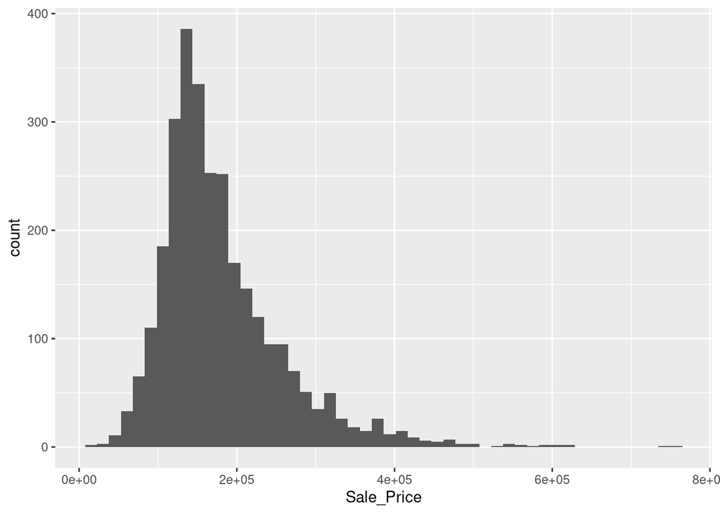

```r
library(ggplot2)
ames %>% ggplot(aes(x = Sale_Price)) + geom_histogram(bins = 50)
```

We see that the sale price is quite skewed. This suggests that a logarithmic transformation of the variable `Sale_Price` could be appropriate. However, taking logarithmic transformation of the response could hinder interpretability as it is not clear how a coefficient now relates to the final `Sale_Price`.

Let us also try to identify potential outliers in the data. We start with a simple scatterplot of `Sale_Price` against `Gr_Liv_Area` (square footage of living area).

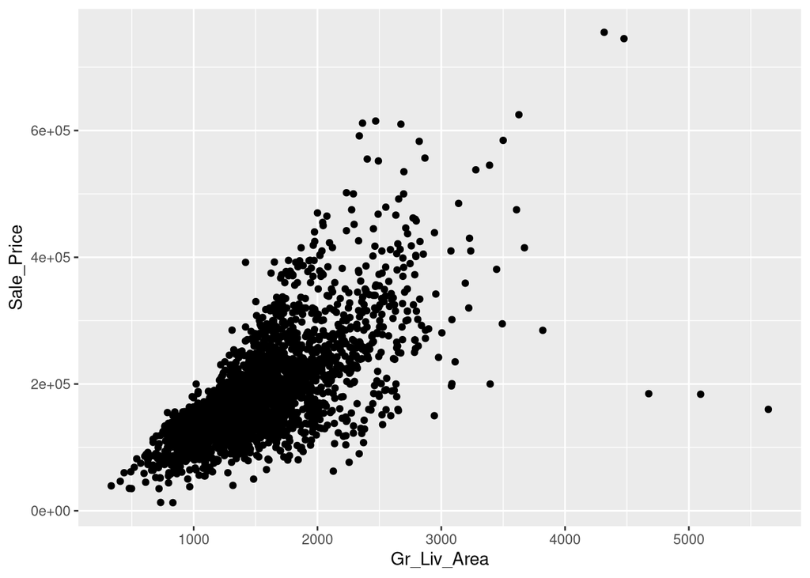

```r
ames %>% ggplot(aes(x = Gr_Liv_Area, y = Sale_Price)) + geom_point()
```

We see that there are five potential outliers, corresponding to house with `Gr_Liv_Area` above $4000$ square foot. Let us take a look at these.

```r
library(dplyr)
ames %>% filter(Gr_Liv_Area >= 4000) %>% select(Gr_Liv_Area, Sale_Price, Sale_Condition)
```

```
## # A tibble: 5 × 3
##   Gr_Liv_Area Sale_Price Sale_Condition
##         <int>      <int> <fct>
## 1        5642     160000 Partial
## 2        4476     745000 Abnorml
## 3        4316     755000 Normal
## 4        5095     183850 Partial
## 5        4676     184750 Partial
```

We will thus choose to remove these data from our modeling. For simplicity, we will also only consider sells for which `Sale_Condition` is `Normal`.

```r
ames_subset <- ames %>% filter(Gr_Liv_Area < 4000, Sale_Condition == "Normal")
ames_subset %>% summarize(count = n())
```

```
## # A tibble: 1 × 1
##   count
##   <int>
## 1  2412
```

### First Modeling Attempt

We now consider a simple model for predicting `Sale_Price`. To get a baseline, we start with a model with only `Gr_Liv_Area` as the predictor variable.

```r
mod0 <- lm(Sale_Price ~ Gr_Liv_Area, data = ames_subset)
summary(mod0)
```

```
##
## Call:
## lm(formula = Sale_Price ~ Gr_Liv_Area, data = ames_subset)
##
## Residuals:
##     Min      1Q  Median      3Q     Max
## -177220  -26873    -878   21564  333582
##
## Coefficients:
##              Estimate Std. Error t value Pr(>|t|)
## (Intercept) 17730.046   3146.244   5.635 1.95e-08 ***
## Gr_Liv_Area   106.756      2.027  52.668  < 2e-16 ***
## ---
## Signif. codes:  0 '***' 0.001 '**' 0.01 '*' 0.05 '.' 0.1 ' ' 1
##
## Residual standard error: 47740 on 2410 degrees of freedom
## Multiple R-squared:  0.5351, Adjusted R-squared:  0.5349
## F-statistic:  2774 on 1 and 2410 DF,  p-value: < 2.2e-16
```

```r
mae_mod0 <- mean(abs(ames_subset$Sale_Price - mod0$fitted.values)) ## Mean Absolute Error
mae_mod0
```

```
## [1] 33557.57
```

Let us now try adding a few more variables to see how much we can reduce these errors. We can add a few variables, starting with the number of bedrooms `Bedroom_AbvGr`, number of bathrooms `Full_Bath` and `Half_Bath`, kitchen quality `Kitchen_Qual`, basement size `Bsmt_Fin_SF_1` and `Bsmt_Fin_SF_2`, and basement quality `BsmtFin_Type_1` and `BsmtFin_Type_2`.

```r
mod1 <- update(mod0, . ~ . + Bedroom_AbvGr + Full_Bath + Half_Bath + Kitchen_Qual + BsmtFin_SF_1 +
                 BsmtFin_SF_2 + BsmtFin_Type_1 + BsmtFin_Type_2)
summary(mod1)
```

```
##
## Call:
## lm(formula = Sale_Price ~ Gr_Liv_Area + Bedroom_AbvGr + Full_Bath +
##     Half_Bath + Kitchen_Qual + BsmtFin_SF_1 + BsmtFin_SF_2 +
##     BsmtFin_Type_1 + BsmtFin_Type_2, data = ames_subset)
##
## Residuals:
##     Min      1Q  Median      3Q     Max
## -216536  -18298    -216   18134  221272
##
## Coefficients: (1 not defined because of singularities)
##                             Estimate Std. Error t value Pr(>|t|)
## (Intercept)                1.591e+05  7.731e+03  20.583  < 2e-16 ***
## Gr_Liv_Area                9.669e+01  2.347e+00  41.203  < 2e-16 ***
## Bedroom_AbvGr             -1.420e+04  1.083e+03 -13.110  < 2e-16 ***
## Full_Bath                  5.128e+03  1.767e+03   2.903  0.00373 **
## Half_Bath                 -2.893e+03  1.548e+03  -1.869  0.06175 .
## Kitchen_QualFair          -1.107e+05  5.530e+03 -20.021  < 2e-16 ***
## Kitchen_QualGood          -7.276e+04  3.363e+03 -21.638  < 2e-16 ***
## Kitchen_QualPoor          -1.032e+05  3.313e+04  -3.115  0.00186 **
## Kitchen_QualTypical       -9.642e+04  3.583e+03 -26.913  < 2e-16 ***
## BsmtFin_SF_1              -3.738e+03  3.700e+02 -10.103  < 2e-16 ***
## BsmtFin_SF_2               3.305e+01  7.067e+00   4.676 3.08e-06 ***
## BsmtFin_Type_1BLQ         -4.094e+03  2.608e+03  -1.570  0.11656
## BsmtFin_Type_1GLQ          2.242e+04  1.911e+03  11.733  < 2e-16 ***
## BsmtFin_Type_1LwQ         -1.375e+04  3.201e+03  -4.295 1.82e-05 ***
## BsmtFin_Type_1No_Basement -7.940e+04  3.337e+04  -2.379  0.01743 *
## BsmtFin_Type_1Rec          3.807e+03  2.492e+03   1.528  0.12671
## BsmtFin_Type_1Unf                 NA         NA      NA       NA
## BsmtFin_Type_2BLQ         -1.013e+04  6.454e+03  -1.569  0.11667
## BsmtFin_Type_2GLQ         -2.314e+02  7.637e+03  -0.030  0.97582
## BsmtFin_Type_2LwQ         -9.137e+03  6.294e+03  -1.452  0.14674
## BsmtFin_Type_2No_Basement  4.544e+04  3.327e+04   1.366  0.17221
## BsmtFin_Type_2Rec         -1.029e+04  6.030e+03  -1.706  0.08813 .
## BsmtFin_Type_2Unf         -2.225e+02  6.149e+03  -0.036  0.97114
## ---
## Signif. codes:  0 '***' 0.001 '**' 0.01 '*' 0.05 '.' 0.1 ' ' 1
##
## Residual standard error: 32890 on 2390 degrees of freedom
## Multiple R-squared:  0.7811, Adjusted R-squared:  0.7792
## F-statistic: 406.2 on 21 and 2390 DF,  p-value: < 2.2e-16
```

```r
mae_mod1 <- mean(abs(ames_subset$Sale_Price - mod1$fitted.values))
mae_mod1
```

```
## [1] 23802.75
```

We see that the error had decreased by roughly a factor or $30%$ for both the `MAE` and `RMSE`. There is, however, the issue that one coefficients is not defined. Let us try to see why this is the case.

```r
ames_subset %>% filter(BsmtFin_Type_1 == "Unf") %>% select(c(contains("BsmtFin"), ends_with("SF")))
```

```
## # A tibble: 644 × 11
##    BsmtFin_Type_1 BsmtFin_SF_1 BsmtFin_Type_2 BsmtFin_SF_2 Bsmt_Unf_SF
##    <fct>                 <dbl> <fct>                 <dbl>       <dbl>
##  1 Unf                       7 Unf                       0         994
##  2 Unf                       7 Unf                       0         763
##  3 Unf                       7 Unf                       0         789
##  4 Unf                       7 Unf                       0         836
##  5 Unf                       7 Unf                       0         764
##  6 Unf                       7 Unf                       0        1324
##  7 Unf                       7 Unf                       0         847
##  8 Unf                       7 Unf                       0         884
##  9 Unf                       7 Unf                       0        1393
## 10 Unf                       7 Unf                       0        1629
## # ℹ 634 more rows
## # ℹ 6 more variables: Total_Bsmt_SF <dbl>, First_Flr_SF <int>,
## #   Second_Flr_SF <int>, Low_Qual_Fin_SF <int>, Wood_Deck_SF <int>,
## #   Open_Porch_SF <int>
```

It turns out that if the basement is unfinished then the square footage is set to a constant value equal to $7$ and this creates a design matrix that is column rank deficient, thereby leading to the singularity in the estimate. We can fix this issue by changing the coding of the data to remove the `Unf` level in the `BsmtFin_Type_1` level by combining it with the `No_Basement` level.

```r
library(forcats)
ames_subset %>% select(BsmtFin_Type_1) %>% pull() %>% table
```

```
## .
##         ALQ         BLQ         GLQ         LwQ No_Basement         Rec
##         378         243         694         136          67         250
##         Unf
##         644
```

```r
ames_subset <- ames_subset %>% mutate(BsmtFin_Type_1 =
                                        fct_collapse(BsmtFin_Type_1, No_Basement = c("No_Basement","Unf")))
mod1 <- update(mod1, data = ames_subset)
summary(mod1)
```

```
##
## Call:
## lm(formula = Sale_Price ~ Gr_Liv_Area + Bedroom_AbvGr + Full_Bath +
##     Half_Bath + Kitchen_Qual + BsmtFin_SF_1 + BsmtFin_SF_2 +
##     BsmtFin_Type_1 + BsmtFin_Type_2, data = ames_subset)
##
## Residuals:
##     Min      1Q  Median      3Q     Max
## -216536  -18298    -216   18134  221272
##
## Coefficients:
##                             Estimate Std. Error t value Pr(>|t|)
## (Intercept)                1.194e+05  1.796e+04   6.649 3.64e-11 ***
## Gr_Liv_Area                9.669e+01  2.347e+00  41.203  < 2e-16 ***
## Bedroom_AbvGr             -1.420e+04  1.083e+03 -13.110  < 2e-16 ***
## Full_Bath                  5.128e+03  1.767e+03   2.903  0.00373 **
## Half_Bath                 -2.893e+03  1.548e+03  -1.869  0.06175 .
## Kitchen_QualFair          -1.107e+05  5.530e+03 -20.021  < 2e-16 ***
## Kitchen_QualGood          -7.276e+04  3.363e+03 -21.638  < 2e-16 ***
## Kitchen_QualPoor          -1.032e+05  3.313e+04  -3.115  0.00186 **
## Kitchen_QualTypical       -9.642e+04  3.583e+03 -26.913  < 2e-16 ***
## BsmtFin_SF_1               3.596e+04  1.669e+04   2.154  0.03132 *
## BsmtFin_SF_2               3.305e+01  7.067e+00   4.676 3.08e-06 ***
## BsmtFin_Type_1BLQ         -4.380e+04  1.691e+04  -2.590  0.00965 **
## BsmtFin_Type_1GLQ         -5.698e+04  3.350e+04  -1.701  0.08914 .
## BsmtFin_Type_1LwQ         -1.329e+05  5.015e+04  -2.649  0.00812 **
## BsmtFin_Type_1No_Basement -2.382e+05  1.001e+05  -2.379  0.01743 *
## BsmtFin_Type_1Rec         -1.947e+05  8.350e+04  -2.332  0.01980 *
## BsmtFin_Type_2BLQ         -1.013e+04  6.454e+03  -1.569  0.11667
## BsmtFin_Type_2GLQ         -2.314e+02  7.637e+03  -0.030  0.97582
## BsmtFin_Type_2LwQ         -9.137e+03  6.294e+03  -1.452  0.14674
## BsmtFin_Type_2No_Basement  4.544e+04  3.327e+04   1.366  0.17221
## BsmtFin_Type_2Rec         -1.029e+04  6.030e+03  -1.706  0.08813 .
## BsmtFin_Type_2Unf         -2.225e+02  6.149e+03  -0.036  0.97114
## ---
## Signif. codes:  0 '***' 0.001 '**' 0.01 '*' 0.05 '.' 0.1 ' ' 1
##
## Residual standard error: 32890 on 2390 degrees of freedom
## Multiple R-squared:  0.7811, Adjusted R-squared:  0.7792
## F-statistic: 406.2 on 21 and 2390 DF,  p-value: < 2.2e-16
```

```r
mae_mod1 <- mean(abs(ames_subset$Sale_Price - mod1$fitted.values))
mae_mod1
```

```
## [1] 23802.75
```

## Second Modeling Attempt.

Let us now continue to add more variables. Looking at the variable list, we can maybe try adding the variables for type of foundation, overall quality of the house, overall condition, house type, and building type, and proximity to various conditions.

```r
mod2 <- update(mod1, . ~ . + Foundation + Overall_Qual + Overall_Cond + Condition_1 + Condition_2 + Bldg_Type + House_Style)
summary(mod2)
```

```
##
## Call:
## lm(formula = Sale_Price ~ Gr_Liv_Area + Bedroom_AbvGr + Full_Bath +
##     Half_Bath + Kitchen_Qual + BsmtFin_SF_1 + BsmtFin_SF_2 +
##     BsmtFin_Type_1 + BsmtFin_Type_2 + Foundation + Overall_Qual +
##     Overall_Cond + Condition_1 + Condition_2 + Bldg_Type + House_Style,
##     data = ames_subset)
##
## Residuals:
##     Min      1Q  Median      3Q     Max
## -123934  -11913    -246   10797  149257
##
## Coefficients:
##                               Estimate Std. Error t value Pr(>|t|)
## (Intercept)                  -9470.120  27052.403  -0.350 0.726321
## Gr_Liv_Area                     83.103      1.895  43.862  < 2e-16 ***
## Bedroom_AbvGr                -6706.605    851.128  -7.880 4.98e-15 ***
## Full_Bath                     4112.307   1373.506   2.994 0.002782 **
## Half_Bath                     6639.760   1361.785   4.876 1.16e-06 ***
## Kitchen_QualFair            -26295.626   4472.116  -5.880 4.69e-09 ***
....
```

```r
mae_mod2 <- mean(abs(ames_subset$Sale_Price - mod2$fitted.values))
mae_mod2
```

```
## [1] 15864.78
```

Looking through the coefficients, it suggest that we can try to remove the variable `Condition_2` without increasing the error much. Let us try that

```r
mod3 <- update(mod2, . ~ . - Condition_2)
summary(mod3)
```

```
##
## Call:
## lm(formula = Sale_Price ~ Gr_Liv_Area + Bedroom_AbvGr + Full_Bath +
##     Half_Bath + Kitchen_Qual + BsmtFin_SF_1 + BsmtFin_SF_2 +
##     BsmtFin_Type_1 + BsmtFin_Type_2 + Foundation + Overall_Qual +
##     Overall_Cond + Condition_1 + Bldg_Type + House_Style, data = ames_subset)
##
## Residuals:
##     Min      1Q  Median      3Q     Max
## -124010  -12056    -249   10849  149453
##
## Coefficients:
##                               Estimate Std. Error t value Pr(>|t|)
## (Intercept)                 -17643.274  21080.684  -0.837 0.402711
## Gr_Liv_Area                     82.942      1.891  43.854  < 2e-16 ***
## Bedroom_AbvGr                -6762.696    849.899  -7.957 2.71e-15 ***
## Full_Bath                     4248.973   1371.560   3.098 0.001972 **
## Half_Bath                     6609.762   1355.523   4.876 1.15e-06 ***
## Kitchen_QualFair            -25908.694   4461.633  -5.807 7.22e-09 ***
## Kitchen_QualGood            -16619.149   3041.579  -5.464 5.15e-08 ***
....
```

```r
mae_mod3 <- mean(abs(ames_subset$Sale_Price - mod3$fitted.values))
mae_mod3
```

```
## [1] 15917.11
```

Let us now try to add in the neighborhood information as each neighborhood could have quite different price points. We may also want to allow for interaction between the neighborhood and the size of the house in each neighborhood.

```r
mod4 <- update(mod3, . ~ . + Neighborhood + Neighborhood*Gr_Liv_Area)
summary(mod4)
```

```
##
## Call:
## lm(formula = Sale_Price ~ Gr_Liv_Area + Bedroom_AbvGr + Full_Bath +
##     Half_Bath + Kitchen_Qual + BsmtFin_SF_1 + BsmtFin_SF_2 +
##     BsmtFin_Type_1 + BsmtFin_Type_2 + Foundation + Overall_Qual +
##     Overall_Cond + Condition_1 + Bldg_Type + House_Style + Neighborhood +
##     Gr_Liv_Area:Neighborhood, data = ames_subset)
##
## Residuals:
##    Min     1Q Median     3Q    Max
## -91967  -9987    -18   9387 117372
##
## Coefficients: (1 not defined because of singularities)
##                                                                   Estimate
## (Intercept)                                                      4.524e+03
## Gr_Liv_Area                                                      6.627e+01
## Bedroom_AbvGr                                                   -5.250e+03
## Full_Bath                                                        4.184e+03
## Half_Bath                                                        3.371e+03
## Kitchen_QualFair                                                -1.924e+04
....
```

```r
mae_mod4 <- mean(abs(ames_subset$Sale_Price - mod4$fitted.values))
mae_mod4
```

```
## [1] 13531.57
```

Nevertheless, the more important question we have to ask is that by introducing the neighborhood variable and its interaction with `Gr_Liv_Area` we had

- Introduced an addition $53$ parameters to the model.
- There are now $115$ coefficients to be estimated.
- Is the jump from $62$ to $115$ parameters merit the
  - reduction in `MAE` by approximately 2400 dollars or
  - reduction in `RMSE` by approximately 2900 dollars ?
- Finally, can the model now be used in say a different city/town where there are no longer the same neighborhood information ?

In light of these issues. We will ignore the neighborhood information and stick with `model3`.

## Evaluating the model.

Let us now suppose that the `MAE` of roughly $16K$ is acceptable to us. Let us now see if there are any noticeable patterns of outliers or non-constant variance in the residuals.

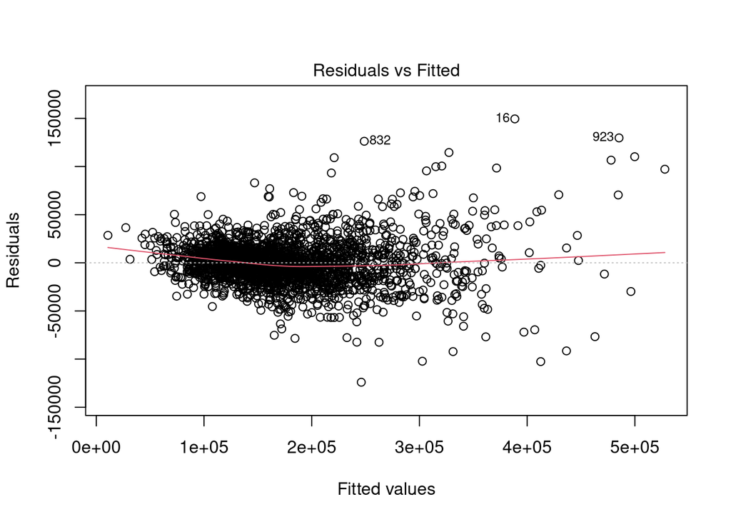

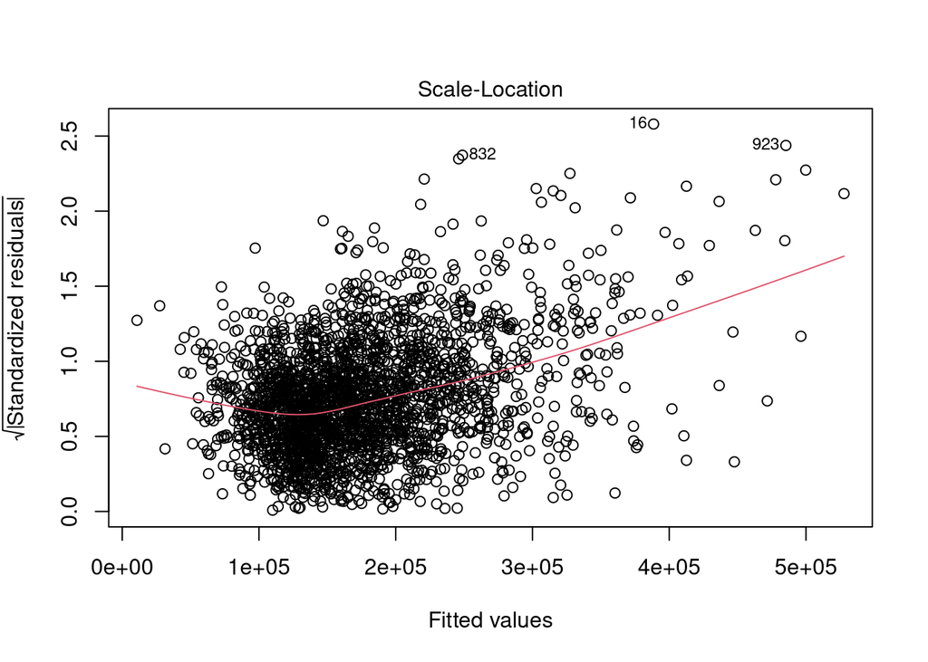

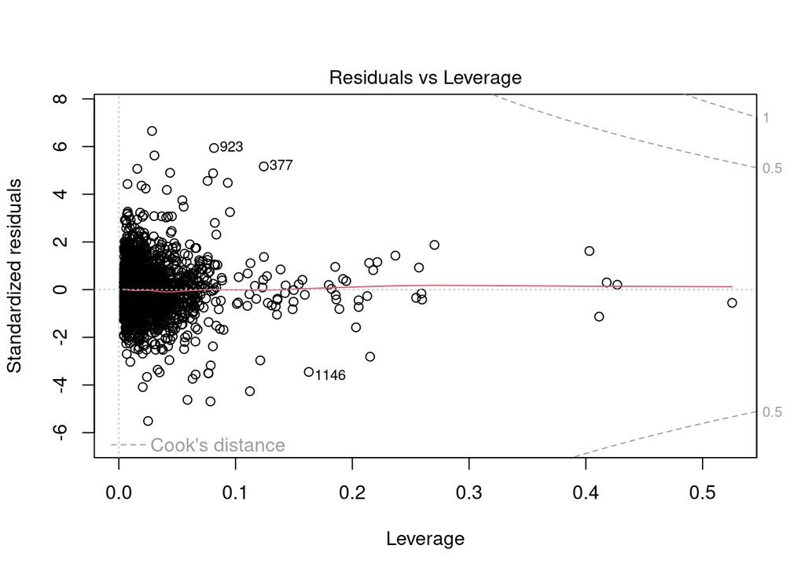

```r
plot(mod3, sub.caption = "", which = c(1,3,5))
```

It is obvious from the second residual vs fitted value plot that there is a sign of non-constant variance. This make sense because the fluctuation in sale price for more expensive houses are in general larger than that for cheaper houses.

We can try to see how well our predictor variables does when we take the log transform of the response variable.

```r
mod3_log_SP <- update(mod3, log(Sale_Price) ~ .)
summary(mod3_log_SP)$sigma
```

```
## [1] 0.1196972
```

```r
mae_mod3_log_SP <- mean(abs(log(ames_subset$Sale_Price) - mod3_log_SP$fitted.values))
mae_mod3_log_SP
```

```
## [1] 0.08845874
```

The above numbers can be interpreted as estimate of the **relative error** in our prediction. So our estimated sale price is roughly $8\% - 12\%$ away from the **expected** sale price. Is this error acceptable ?

## Simplifying the model.t

We will now assume that `mod3` is acceptable. Let us see if we can find a simpler model with similar error. We first start by trying to ignore the variables associated with `BsmtFin_Type_2` and `BsmtFin_SF_2`.

```r
mod3_simp1 <- update(mod3, . ~ . - BsmtFin_SF_2 - BsmtFin_Type_2)
summary(mod3_simp1)
```

```
##
## Call:
## lm(formula = Sale_Price ~ Gr_Liv_Area + Bedroom_AbvGr + Full_Bath +
##     Half_Bath + Kitchen_Qual + BsmtFin_SF_1 + BsmtFin_Type_1 +
##     Foundation + Overall_Qual + Overall_Cond + Condition_1 +
##     Bldg_Type + House_Style, data = ames_subset)
##
## Residuals:
##     Min      1Q  Median      3Q     Max
## -128039  -12367    -392   10976  148051
##
## Coefficients:
##                               Estimate Std. Error t value Pr(>|t|)
## (Intercept)                 -15976.295  17491.604  -0.913 0.361142
## Gr_Liv_Area                     83.467      1.899  43.955  < 2e-16 ***
## Bedroom_AbvGr                -7157.081    852.078  -8.400  < 2e-16 ***
## Full_Bath                     4172.614   1379.602   3.025 0.002517 **
## Half_Bath                     6651.638   1363.278   4.879 1.14e-06 ***
## Kitchen_QualFair            -26444.644   4486.178  -5.895 4.29e-09 ***
## Kitchen_QualGood            -17104.666   3059.279  -5.591 2.52e-08 ***
## Kitchen_QualPoor              5609.000  23636.240   0.237 0.812441
## Kitchen_QualTypical         -23390.416   3249.921  -7.197 8.22e-13 ***
## BsmtFin_SF_1                  4566.351   2427.776   1.881 0.060112 .
## BsmtFin_Type_1BLQ           -11309.334   3120.774  -3.624 0.000296 ***
## BsmtFin_Type_1GLQ            -4140.937   5086.589  -0.814 0.415676
## BsmtFin_Type_1LwQ           -25396.939   7674.721  -3.309 0.000950 ***
## BsmtFin_Type_1No_Basement   -45781.163  14454.436  -3.167 0.001558 **
## BsmtFin_Type_1Rec           -31985.172  12325.074  -2.595 0.009514 **
## FoundationCBlock              9249.778   1836.226   5.037 5.08e-07 ***
## FoundationPConc              17124.679   2048.617   8.359  < 2e-16 ***
## FoundationSlab                3836.775   6073.860   0.632 0.527653
## FoundationStone              -6114.597   7534.399  -0.812 0.417128
## FoundationWood               -5618.669  10465.864  -0.537 0.591417
## Overall_QualPoor              8394.965  15846.519   0.530 0.596323
## Overall_QualFair              5277.908  15132.138   0.349 0.727280
## Overall_QualBelow_Average     9818.399  14909.342   0.659 0.510256
## Overall_QualAverage          17249.211  14918.576   1.156 0.247707
## Overall_QualAbove_Average    27114.418  14966.823   1.812 0.070170 .
## Overall_QualGood             39997.681  15027.054   2.662 0.007827 **
## Overall_QualVery_Good        73806.585  15099.183   4.888 1.09e-06 ***
```

[output cut: 20 more lines]

```
## Bldg_TypeTwnhs              -23528.738   2644.285  -8.898  < 2e-16 ***
## Bldg_TypeTwnhsE             -18796.883   1977.008  -9.508  < 2e-16 ***
## House_StyleOne_and_Half_Unf  20915.584   5594.146   3.739 0.000189 ***
## House_StyleOne_Story         24139.609   1824.409  13.231  < 2e-16 ***
## House_StyleSFoyer            28776.160   3497.400   8.228 3.11e-16 ***
## House_StyleSLvl              13322.170   2750.145   4.844 1.35e-06 ***
## House_StyleTwo_and_Half_Fin -42417.619   9820.230  -4.319 1.63e-05 ***
## House_StyleTwo_and_Half_Unf -16985.302   5305.647  -3.201 0.001386 **
## House_StyleTwo_Story         -1160.849   1934.781  -0.600 0.548571
## ---
## Signif. codes:  0 '***' 0.001 '**' 0.01 '*' 0.05 '.' 0.1 ' ' 1
##
## Residual standard error: 22940 on 2356 degrees of freedom
## Multiple R-squared:  0.8951, Adjusted R-squared:  0.8927
## F-statistic: 365.6 on 55 and 2356 DF,  p-value: < 2.2e-16
```

```r
mae_mod3_simp1<- mean(abs(ames_subset$Sale_Price - mod3_simp1$fitted.values))
mae_mod3_simp1
```

```
## [1] 16001.69
```

```r
library(MASS)
mod3_stepAIC <- stepAIC(mod3, direction = "both")
```

```
## Start:  AIC=48464.49
## Sale_Price ~ Gr_Liv_Area + Bedroom_AbvGr + Full_Bath + Half_Bath +
##     Kitchen_Qual + BsmtFin_SF_1 + BsmtFin_SF_2 + BsmtFin_Type_1 +
##     BsmtFin_Type_2 + Foundation + Overall_Qual + Overall_Cond +
##     Condition_1 + Bldg_Type + House_Style
##
##                  Df  Sum of Sq        RSS   AIC
## - BsmtFin_SF_1    1 5.6785e+08 1.2196e+12 48464
## <none>                         1.2190e+12 48464
## - BsmtFin_Type_2  6 9.6599e+09 1.2286e+12 48472
## - Full_Bath       1 4.9803e+09 1.2240e+12 48472
## - BsmtFin_SF_2    1 5.3434e+09 1.2243e+12 48473
## - Half_Bath       1 1.2339e+10 1.2313e+12 48487
## - Condition_1     8 3.0844e+10 1.2498e+12 48509
## - Kitchen_Qual    4 2.9314e+10 1.2483e+12 48514
## - Bedroom_AbvGr   1 3.2857e+10 1.2518e+12 48527
## - Foundation      5 4.0029e+10 1.2590e+12 48532
## - Overall_Cond    8 5.1183e+10 1.2702e+12 48548
## - BsmtFin_Type_1  5 5.9790e+10 1.2788e+12 48570
## - Bldg_Type       4 1.1453e+11 1.3335e+12 48673
## - House_Style     7 1.5635e+11 1.3753e+12 48742
## - Overall_Qual    9 6.3196e+11 1.8510e+12 49454
## - Gr_Liv_Area     1 9.9802e+11 2.2170e+12 49905
##
## Step:  AIC=48463.61
## Sale_Price ~ Gr_Liv_Area + Bedroom_AbvGr + Full_Bath + Half_Bath +
##     Kitchen_Qual + BsmtFin_SF_2 + BsmtFin_Type_1 + BsmtFin_Type_2 +
##     Foundation + Overall_Qual + Overall_Cond + Condition_1 +
##     Bldg_Type + House_Style
##
##                  Df  Sum of Sq        RSS   AIC
## <none>                         1.2196e+12 48464
## + BsmtFin_SF_1    1 5.6785e+08 1.2190e+12 48464
## - Full_Bath       1 4.9893e+09 1.2245e+12 48471
## - BsmtFin_SF_2    1 5.7538e+09 1.2253e+12 48473
## - BsmtFin_Type_2  6 1.0956e+10 1.2305e+12 48473
## - Half_Bath       1 1.2298e+10 1.2319e+12 48486
## - Condition_1     8 3.0923e+10 1.2505e+12 48508
## - Kitchen_Qual    4 2.9244e+10 1.2488e+12 48513
## - Bedroom_AbvGr   1 3.2648e+10 1.2522e+12 48525
## - Foundation      5 4.0181e+10 1.2597e+12 48532
## - Overall_Cond    8 5.1173e+10 1.2707e+12 48547
## - Bldg_Type       4 1.1484e+11 1.3344e+12 48673
## - House_Style     7 1.5626e+11 1.3758e+12 48740
## - BsmtFin_Type_1  5 1.6852e+11 1.3881e+12 48766
## - Overall_Qual    9 6.3427e+11 1.8538e+12 49456
## - Gr_Liv_Area     1 9.9748e+11 2.2170e+12 49903
```

```r
summary(mod3_stepAIC)
```

```
##
## Call:
## lm(formula = Sale_Price ~ Gr_Liv_Area + Bedroom_AbvGr + Full_Bath +
##     Half_Bath + Kitchen_Qual + BsmtFin_SF_2 + BsmtFin_Type_1 +
##     BsmtFin_Type_2 + Foundation + Overall_Qual + Overall_Cond +
##     Condition_1 + Bldg_Type + House_Style, data = ames_subset)
##
## Residuals:
##     Min      1Q  Median      3Q     Max
## -124098  -12118    -259   10851  149434
##
## Coefficients:
##                               Estimate Std. Error t value Pr(>|t|)
## (Intercept)                  -5819.234  17794.466  -0.327 0.743678
## Gr_Liv_Area                     82.885      1.891  43.841  < 2e-16 ***
## Bedroom_AbvGr                -6738.696    849.607  -7.932 3.32e-15 ***
## Full_Bath                     4252.801   1371.583   3.101 0.001954 **
## Half_Bath                     6598.584   1355.508   4.868 1.20e-06 ***
## Kitchen_QualFair            -25841.139   4461.255  -5.792 7.87e-09 ***
## Kitchen_QualGood            -16579.648   3041.406  -5.451 5.52e-08 ***
## Kitchen_QualPoor              5211.499  23477.257   0.222 0.824348
## Kitchen_QualTypical         -22477.718   3234.016  -6.950 4.70e-12 ***
## BsmtFin_SF_2                    16.392      4.923   3.330 0.000883 ***
## BsmtFin_Type_1BLQ            -7905.491   1938.741  -4.078 4.70e-05 ***
## BsmtFin_Type_1GLQ             5330.164   1704.344   3.127 0.001785 **
## BsmtFin_Type_1LwQ           -16016.614   2452.168  -6.532 7.95e-11 ***
## BsmtFin_Type_1No_Basement   -18703.238   1643.157 -11.383  < 2e-16 ***
## BsmtFin_Type_1Rec           -11300.304   1965.436  -5.750 1.01e-08 ***
## BsmtFin_Type_2BLQ           -10197.588   4507.475  -2.262 0.023765 *
## BsmtFin_Type_2GLQ            -1586.890   5353.308  -0.296 0.766927
## BsmtFin_Type_2LwQ           -11700.477   4415.173  -2.650 0.008102 **
## BsmtFin_Type_2No_Basement   -13607.003   6356.951  -2.140 0.032418 *
## BsmtFin_Type_2Rec           -12471.557   4203.071  -2.967 0.003035 **
## BsmtFin_Type_2Unf            -5162.305   4303.389  -1.200 0.230419
## FoundationCBlock              9234.792   1827.739   5.053 4.69e-07 ***
## FoundationPConc              16784.916   2035.965   8.244 2.73e-16 ***
## FoundationSlab                3062.948   5964.180   0.514 0.607610
## FoundationStone              -6038.543   7484.182  -0.807 0.419840
## FoundationWood               -4716.217  10413.993  -0.453 0.650682
## Overall_QualPoor              8293.638  15739.981   0.527 0.598302
```

[output cut: 26 more lines]

```
## Bldg_TypeTwnhs              -23762.373   2628.213  -9.041  < 2e-16 ***
## Bldg_TypeTwnhsE             -18999.318   1967.059  -9.659  < 2e-16 ***
## House_StyleOne_and_Half_Unf  20673.810   5558.803   3.719 0.000205 ***
## House_StyleOne_Story         23279.416   1822.631  12.772  < 2e-16 ***
## House_StyleSFoyer            27144.769   3497.032   7.762 1.24e-14 ***
## House_StyleSLvl              11510.201   2756.129   4.176 3.07e-05 ***
## House_StyleTwo_and_Half_Fin -41809.744   9754.895  -4.286 1.89e-05 ***
## House_StyleTwo_and_Half_Unf -16787.330   5271.119  -3.185 0.001468 **
## House_StyleTwo_Story         -1745.337   1924.624  -0.907 0.364581
## ---
## Signif. codes:  0 '***' 0.001 '**' 0.01 '*' 0.05 '.' 0.1 ' ' 1
##
## Residual standard error: 22780 on 2350 degrees of freedom
## Multiple R-squared:  0.8968, Adjusted R-squared:  0.8941
## F-statistic: 334.7 on 61 and 2350 DF,  p-value: < 2.2e-16
```

```r
mod3_simp1_stepAIC <- stepAIC(mod3_simp1, direction = "both")
```

```
## Start:  AIC=48490.42
## Sale_Price ~ Gr_Liv_Area + Bedroom_AbvGr + Full_Bath + Half_Bath +
##     Kitchen_Qual + BsmtFin_SF_1 + BsmtFin_Type_1 + Foundation +
##     Overall_Qual + Overall_Cond + Condition_1 + Bldg_Type + House_Style
##
##                  Df  Sum of Sq        RSS   AIC
## <none>                         1.2393e+12 48490
## - BsmtFin_SF_1    1 1.8610e+09 1.2412e+12 48492
## - Full_Bath       1 4.8120e+09 1.2441e+12 48498
## - Half_Bath       1 1.2523e+10 1.2519e+12 48513
## - Condition_1     8 3.1669e+10 1.2710e+12 48535
## - Kitchen_Qual    4 3.1920e+10 1.2713e+12 48544
## - Bedroom_AbvGr   1 3.7113e+10 1.2765e+12 48560
## - Foundation      5 4.2019e+10 1.2814e+12 48561
## - Overall_Cond    8 5.2797e+10 1.2921e+12 48575
## - BsmtFin_Type_1  5 5.9769e+10 1.2991e+12 48594
## - Bldg_Type       4 1.1213e+11 1.3515e+12 48691
## - House_Style     7 1.6478e+11 1.4041e+12 48778
## - Overall_Qual    9 6.4184e+11 1.8812e+12 49479
## - Gr_Liv_Area     1 1.0163e+12 2.2557e+12 49933
```

```r
summary(mod3_simp1_stepAIC)
```

```
##
## Call:
## lm(formula = Sale_Price ~ Gr_Liv_Area + Bedroom_AbvGr + Full_Bath +
##     Half_Bath + Kitchen_Qual + BsmtFin_SF_1 + BsmtFin_Type_1 +
##     Foundation + Overall_Qual + Overall_Cond + Condition_1 +
##     Bldg_Type + House_Style, data = ames_subset)
##
## Residuals:
##     Min      1Q  Median      3Q     Max
## -128039  -12367    -392   10976  148051
##
## Coefficients:
##                               Estimate Std. Error t value Pr(>|t|)
## (Intercept)                 -15976.295  17491.604  -0.913 0.361142
## Gr_Liv_Area                     83.467      1.899  43.955  < 2e-16 ***
## Bedroom_AbvGr                -7157.081    852.078  -8.400  < 2e-16 ***
## Full_Bath                     4172.614   1379.602   3.025 0.002517 **
## Half_Bath                     6651.638   1363.278   4.879 1.14e-06 ***
## Kitchen_QualFair            -26444.644   4486.178  -5.895 4.29e-09 ***
## Kitchen_QualGood            -17104.666   3059.279  -5.591 2.52e-08 ***
## Kitchen_QualPoor              5609.000  23636.240   0.237 0.812441
## Kitchen_QualTypical         -23390.416   3249.921  -7.197 8.22e-13 ***
## BsmtFin_SF_1                  4566.351   2427.776   1.881 0.060112 .
## BsmtFin_Type_1BLQ           -11309.334   3120.774  -3.624 0.000296 ***
## BsmtFin_Type_1GLQ            -4140.937   5086.589  -0.814 0.415676
## BsmtFin_Type_1LwQ           -25396.939   7674.721  -3.309 0.000950 ***
## BsmtFin_Type_1No_Basement   -45781.163  14454.436  -3.167 0.001558 **
## BsmtFin_Type_1Rec           -31985.172  12325.074  -2.595 0.009514 **
## FoundationCBlock              9249.778   1836.226   5.037 5.08e-07 ***
## FoundationPConc              17124.679   2048.617   8.359  < 2e-16 ***
## FoundationSlab                3836.775   6073.860   0.632 0.527653
## FoundationStone              -6114.597   7534.399  -0.812 0.417128
## FoundationWood               -5618.669  10465.864  -0.537 0.591417
## Overall_QualPoor              8394.965  15846.519   0.530 0.596323
## Overall_QualFair              5277.908  15132.138   0.349 0.727280
## Overall_QualBelow_Average     9818.399  14909.342   0.659 0.510256
## Overall_QualAverage          17249.211  14918.576   1.156 0.247707
## Overall_QualAbove_Average    27114.418  14966.823   1.812 0.070170 .
## Overall_QualGood             39997.681  15027.054   2.662 0.007827 **
## Overall_QualVery_Good        73806.585  15099.183   4.888 1.09e-06 ***
```

[output cut: 20 more lines]

```
## Bldg_TypeTwnhs              -23528.738   2644.285  -8.898  < 2e-16 ***
## Bldg_TypeTwnhsE             -18796.883   1977.008  -9.508  < 2e-16 ***
## House_StyleOne_and_Half_Unf  20915.584   5594.146   3.739 0.000189 ***
## House_StyleOne_Story         24139.609   1824.409  13.231  < 2e-16 ***
## House_StyleSFoyer            28776.160   3497.400   8.228 3.11e-16 ***
## House_StyleSLvl              13322.170   2750.145   4.844 1.35e-06 ***
## House_StyleTwo_and_Half_Fin -42417.619   9820.230  -4.319 1.63e-05 ***
## House_StyleTwo_and_Half_Unf -16985.302   5305.647  -3.201 0.001386 **
## House_StyleTwo_Story         -1160.849   1934.781  -0.600 0.548571
## ---
## Signif. codes:  0 '***' 0.001 '**' 0.01 '*' 0.05 '.' 0.1 ' ' 1
##
## Residual standard error: 22940 on 2356 degrees of freedom
## Multiple R-squared:  0.8951, Adjusted R-squared:  0.8927
## F-statistic: 365.6 on 55 and 2356 DF,  p-value: < 2.2e-16
```

In conclusion, the model `mod3` appear to provide a nice balance between complexity and accuracy.

## But wait, there is more.

- Our whole procedure is done based on using the data to estimate the parameters and then using the fitted model to evaluate the error.
- As we said earlier in our lecture slides, the error estimate is likely to be overly optimistic.
- We could split the data into training data and test data and use the training data to estimate the coefficients and use the test data to evaluate the error.
- Model selection is now quite a bit harder to automate. However, automatic model selection is also a controversial topic, so maybe this is not such a big issue.